# ronxmaps: managing OnX Maps Markups from R

Robert Ritson

2026-07-23

## Getting started

Here we are going to get started using the `ronxmaps` R package. Before you begin, you must have a valid OnX user account. “Hunt” accounts will likely work best.

### Installation from GitHub (development version)

```r
install.packages("remotes")
remotes::install_github("r2j2ritson/ronxmaps")
library(ronxmaps)
```

### Loging in to your OnX account

Run this in the console rather saving in a script in order to protect your account information. This information is stored in the system environment so you it can be discretely accessed when needed.

```r
ronxmaps::setCredentials(onx_email = "myonx_email@example.com",
                         onx_password = "myonxpassword")
```

```
#> OnX Credentials set in system environment.
```

You can check that your credential are correctly stored in the environment by running the following:

```r
Sys.getenv('ONX_EMAIL')
```

```
#> [1] "myonx_email@example.com"
```

```r
Sys.getenv('ONX_PASSWORD')
```

```
#> [1] "myonxpassword"
```

### Generate access token

Now that your information is discretely stored, you can then generate an access token for the OnX Web Maps API. This function can be re-run at anytime to generate a new access token or check how much more time is left on your current token. This may need to be repeated a few times before token is correctly acquired.

```r
ronxmaps::getToken(onx_email = Sys.getenv('ONX_EMAIL'),
                   onx_password = Sys.getenv('ONX_PASSWORD'),
                   url = ronxmaps::onx_login_base(),
                   verbose = T)
```

```
#> Old Access Token Expires in  24 minutes.
```

### View basic profile and subscription information

If successful, you should now be able to check your profile information to confirm you have access to the API.

```r
ronxmaps::onx_subscriptions()
```

```
#> # A tibble: 1 × 6
#>   Hunt  Hunt_Started         Hunt_Expires         Offroad Fish  Backcountry
#>   <chr> <chr>                <chr>                <chr>   <chr> <chr>
#> 1 elite 2026-01-15T18:55:50Z 2027-01-15T23:59:59Z basic   basic basic
```

Congratulations! You officially have access to the OnX Maps Web API through R!

## Down to business: Managing your Markups!

### View Content

```r
myPts <- ronxmaps::onx_list_markups(markup_type = "waypoints",parse=T)
head(myPts)
```

```
#>                  name     type                                 uuid
#> 1 Lacy Meadows Trap 4 waypoint 6365c35b-a128-4f9f-bf8e-d763c2de4165
#> 2 Lacy Meadows Trap 1 waypoint bc860f96-71b6-4578-874e-b1ea06c68d45
#> 3 Lacy Meadows Trap 2 waypoint e8c2a570-534c-4f08-ae30-a95886916dd5
#> 4     ford creek trap waypoint 36e19c0e-94c4-4457-9bce-7df8f8e5d512
#> 5 Lacy Meadows Trap 3 waypoint 473bf72b-8e48-4c11-aa1f-2e600fc56cf9
#> 6                LC 1 waypoint c908ed9c-6aec-4231-b60d-1854638f9ac1
#>                    updated_at geo_json.geometry.type geo_json.type
#> 1 2020-07-09T15:30:47.000000Z                  Point       Feature
#> 2 2020-07-09T15:30:47.000000Z                  Point       Feature
#> 3 2020-07-09T15:30:45.000000Z                  Point       Feature
#> 4 2020-04-24T16:46:31.000000Z                  Point       Feature
#> 5 2020-04-24T16:46:31.000000Z                  Point       Feature
#> 6 2020-07-09T15:30:42.000000Z                  Point       Feature
#>                    created_at has_active_shares                      geometry
#> 1 2020-01-27T06:32:58.000000Z              <NA> POINT Z (-115.8351 46.2978 0)
#> 2 2020-01-27T06:32:58.000000Z              <NA> POINT Z (-115.8653 46.3402 0)
#> 3 2020-01-27T21:13:09.000000Z              <NA> POINT Z (-115.8467 46.2991 0)
#> 4 2020-01-28T20:15:49.000000Z              <NA> POINT Z (-116.0861 46.4464 0)
#> 5 2020-01-29T01:44:22.000000Z              <NA> POINT Z (-115.8405 46.2982 0)
#> 6 2020-01-29T18:33:44.000000Z              <NA> POINT Z (-115.9894 46.2825 0)
```

```r
myPts_raw <- ronxmaps::onx_list_markups(markup_type = "waypoints",parse=F)
myPts_raw[[100]]
```

[output not shown]

[output cut: 27 more lines]

[output not shown]

```r
myTracks <- ronxmaps::onx_list_markups(markup_type = "tracks",parse=T)
head(myTracks)
```

```
#>                   name  type                                 uuid
#> 1 Track 04/22/20 15:28 track 648d43af-6bac-4fdd-9d63-c1b4c9344eb9
#> 2 Track 04/27/20 14:15 track 2803818e-0e4d-4096-a355-d1fd6392a9f3
#>                    updated_at geo_json.geometry.type geo_json.type
#> 1 2020-04-22T22:28:49.000000Z             LineString       Feature
#> 2 2020-04-27T21:15:19.000000Z             LineString       Feature
#>                    created_at has_active_shares                       geometry
#> 1 2020-04-22T22:28:49.000000Z             FALSE LINESTRING Z (-115.9604 46....
#> 2 2020-04-27T21:15:19.000000Z             FALSE LINESTRING Z (-116.1401 46....
```

```r
myPolys <- ronxmaps::onx_list_markups(markup_type = "shapes",parse=T)
head(myPolys)
```

```
#>                                                name  type
#> 1 Imported shape markup 2025-08-28T17:06:14.905765Z shape
#> 2 Imported shape markup 2025-08-28T17:06:14.905919Z shape
#> 3 Imported shape markup 2025-08-28T17:06:14.906103Z shape
#> 4 Imported shape markup 2025-08-28T17:06:14.906317Z shape
#> 5 Imported shape markup 2025-08-28T17:06:14.906518Z shape
#> 6 Imported shape markup 2025-08-28T17:06:14.906702Z shape
#>                                   uuid                  updated_at
#> 1 186f0031-87f6-4d62-b5bd-d934e0240ebb 2025-08-28T17:06:14.905841Z
#> 2 6fd58f7f-d378-4e35-8b75-c49ebe90d927 2025-08-28T17:06:14.906033Z
#> 3 f2866e47-1281-46bb-84c6-28d8e4c1bf36 2025-08-28T17:06:14.906218Z
#> 4 36a0f8d9-5fa8-4c4c-86a8-73f76fc77891 2025-08-28T17:06:14.906433Z
#> 5 9d2ff833-09ed-4c0d-a2d6-f4e3db01949d 2025-08-28T17:06:14.906647Z
#> 6 9146eb10-5405-4c6a-bcf1-e2eff53c4fdf 2025-08-28T17:06:14.906776Z
#>   geo_json.geometry.type geo_json.type                  created_at
#> 1                Polygon       Feature 2025-08-28T17:06:14.905840Z
#> 2                Polygon       Feature 2025-08-28T17:06:14.906031Z
#> 3                Polygon       Feature 2025-08-28T17:06:14.906217Z
#> 4                Polygon       Feature 2025-08-28T17:06:14.906427Z
#> 5                Polygon       Feature 2025-08-28T17:06:14.906646Z
#> 6                Polygon       Feature 2025-08-28T17:06:14.906775Z
#>   has_active_shares                       geometry
#> 1             FALSE POLYGON Z ((-116.3564 47.13...
#> 2             FALSE POLYGON Z ((-116.3571 47.14...
#> 3             FALSE POLYGON Z ((-116.3606 47.14...
#> 4             FALSE POLYGON Z ((-116.3602 47.14...
#> 5             FALSE POLYGON Z ((-116.3597 47.14...
#> 6             FALSE POLYGON Z ((-116.3593 47.14...
```

```r
ronxmaps::plot_markups(markup_type = "waypoints",interactive = T)
```

[interactive chart not shown]

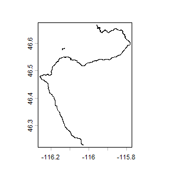

```r
ronxmaps::plot_markups(markup_type = "tracks",interactive = F)
```

### Save Content

```r
polys_sf <- sf::st_as_sf(myPolys)
head(polys_sf)
```

```
#> Simple feature collection with 6 features and 8 fields
#> Geometry type: POLYGON
#> Dimension:     XYZ
#> Bounding box:  xmin: -116.364 ymin: 47.1308 xmax: -116.3563 ymax: 47.1502
#> z_range:       zmin: 0 zmax: 0
#> Geodetic CRS:  WGS 84
#>                                                name  type
#> 1 Imported shape markup 2025-08-28T17:06:14.905765Z shape
#> 2 Imported shape markup 2025-08-28T17:06:14.905919Z shape
#> 3 Imported shape markup 2025-08-28T17:06:14.906103Z shape
#> 4 Imported shape markup 2025-08-28T17:06:14.906317Z shape
#> 5 Imported shape markup 2025-08-28T17:06:14.906518Z shape
#> 6 Imported shape markup 2025-08-28T17:06:14.906702Z shape
#>                                   uuid                  updated_at
#> 1 186f0031-87f6-4d62-b5bd-d934e0240ebb 2025-08-28T17:06:14.905841Z
```

[output cut: 19 more lines]

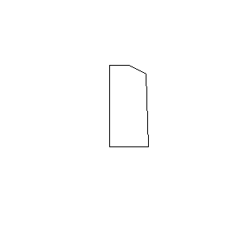

```r
plot(polys_sf[1,"geometry"])
```

```r
sf::st_write(polys_sf,"myOnXPolys.shp")
```

### Import Content

The package includes several internal files for testing uploads (a point `BorahPeak_kml`, a track `BorahPeakTrail_kml`, and a polygon`BorahPeakUSGSQuad_kml`).

```r
test_file <- ronxmaps::BorahPeak_kml
sf::st_write(test_file,"test_file.kml")
file <- file.path(getwd(),"test_file.kml")
import_kml2OnX(file = file, token = Sys.getenv("ONX_TOKEN", unset = ""))
```

### Delete Content

```r
ronxmaps::delete_markup(myPolys$uuid[1])
```

### View folders

```r
folders <- ronxmaps::onx_content_collections(parse = T,include_entities = F)
head(folders)
```

```
#>                                   uuid                   name
#> 1 b3d4f112-d023-43ae-b105-f22c68f04a44 New Folder Test July 6
#> 2 8d86589f-f3b2-4993-868c-62cfd1e50a0d            IDFG Cabins
#> 3 7c857382-13a1-40d1-8b95-eda0c6fda9cd   Import 07/01/26 8:52
#> 4 a51a46b7-d1c8-4e53-bb35-a72a5641dd1d                   CSTG
#>                             created_by           created_at
#> 1 fb617ab9-6a9b-428c-b954-6ba1bb569f67 2026-07-06T17:59:05Z
#> 2 fb617ab9-6a9b-428c-b954-6ba1bb569f67 2025-09-15T21:22:58Z
#> 3 fb617ab9-6a9b-428c-b954-6ba1bb569f67 2026-07-01T14:52:40Z
#> 4 fb617ab9-6a9b-428c-b954-6ba1bb569f67 2025-04-02T17:33:08Z
#>             updated_at type permissions1          permissions2
#> 1 2026-07-06T17:59:05Z hunt        share collection.add_entity
#> 2 2025-09-15T21:33:06Z hunt        share collection.add_entity
#> 3 2026-07-01T14:52:40Z hunt        share collection.add_entity
#> 4 2025-04-02T18:08:08Z hunt        share collection.add_entity
#>        permissions3      permissions4   permissions5 entity_count
#> 1 collection.update collection.delete collection.get            0
#> 2 collection.update collection.delete collection.get           19
#> 3 collection.update collection.delete collection.get            0
#> 4 collection.update collection.delete collection.get            4
```